# R Notebook

Combining 2 dat asets

ps_merge <- merge_phyloseq(pseq, atlas1006)

get_variable(batmicrobiome,“LONGITUDE” )

sample_data(batmicrobiome)

sample_names(batmicrobiome)

batmicrobiome[LONGITUDE] <- sample(50:1000)

sample_data(atlas1006)$human = factor( get_variable(atlas1006) %in% c(“Feces”, “Mock”, “Skin”, “Tongue”) )

sample_data(atlas1006)$human = sample(50:1000)

sample_data(atlas1006)$human = rep(3,1151) %%% THIS WORKS !!!!

sample_data(atlas1006)$LATITUDE = rep(17,1151) sample_data(atlas1006)$LONGITUDE = rep(-77,1151) get_variable(atlas1006,“LATITUDE” ) map_phyloseq(atlas1006)

map_phyloseq(batmicrobiome)

rep(3,12)

devtools::install_github(“UrbanInstitute/urbnmapr”)

atlas1006

sample_variables(atlas1006)

sample_variables(batmicrobiome)[56] THIS WORKS

batmicrobiome = sample_data(data.frame( LONGITUDE = sample(50:1000)))

[output not shown]

Location = sample(LETTERS[1:4], size=nsamples(physeq), replace=TRUE), Depth = sample(50:1000, size=nsamples(physeq), replace=TRUE), row.names=sample_names(physeq), stringsAsFactors=FALSE

sampledata = sample_data(data.frame( Location = sample(LETTERS[1:4], size=nsamples(physeq), replace=TRUE), Depth = sample(50:1000, size=nsamples(physeq), replace=TRUE), row.names=sample_names(physeq), stringsAsFactors=FALSE ))

```r
    setwd("/Users/rezahaji-dehabadi/scripts/workspace")
```

```
The working directory was changed to /Users/rezahaji-dehabadi/scripts/workspace inside a notebook chunk. The working directory will be reset when the chunk is finished running. Use the knitr root.dir option in the setup chunk to change the working directory for notebook chunks.
```

```r
    ## Get data
    library(foreign)
    library(stargazer)
    library(psych)
    library(plyr)
    library(xtable)
    library(car)
    #library(dplyr)
    library(scales)
    library(reshape)
    library(gmodels)
    library(nnet)
    library(tidyr)
    library(sjmisc)
    library(RColorBrewer)
  library(htmltools)
    library(broom)
library(hrbrthemes)
library(gcookbook)
library(tidyverse)
library(gdtools)
library(phyloseq)
library(microbiome)
library(knitr)
library(ggpubr)
library(phylogeo)
data(atlas1006)
# Rename the example data (which is a phyloseq object)
pseq <- atlas1006
```

```r
tab <- global(pseq, index = "all")
```

```
Richness
Observed (richness 0)
Diversity
Evenness
Dominance
Rarity
```

```r
stargazer(tab, type = "text")
```

```
==========================================================================================
Statistic                     N      Mean      St. Dev.    Min   Pctl(25) Pctl(75)   Max
------------------------------------------------------------------------------------------
richness_0                  1,172   113.020      4.170     107     111      114      130
richness_20                 1,172   103.821      4.617      95     100      107      130
richness_50                 1,172   64.996       5.029      45      62       68      89
richness_80                 1,172   25.998       6.812      5       22       31      50
observed                    1,172   130.000      0.000     130     130      130      130
diversities_inverse_simpson 1,172   11.073       4.999    1.762   7.380    14.450  27.898
diversities_gini_simpson    1,172    0.879       0.085    0.433   0.865    0.931    0.964
diversities_shannon         1,172    2.985       0.419    1.264   2.816    3.266    3.784
diversities_fisher          1,172   11.887       0.527    10.801  11.520   12.169  14.401
diversities_coverage        1,172    4.465       1.970      1       3        6       11
evenness_camargo            1,172    0.141       0.035    0.043   0.120    0.164    0.270
evenness_pielou             1,172    0.613       0.086    0.260   0.578    0.671    0.777
evenness_simpson            1,172    0.085       0.038    0.014   0.057    0.111    0.215
evenness_evar               1,172    0.072       0.013    0.057   0.065    0.075    0.190
evenness_bulla              1,172    0.281       0.043    0.117   0.258    0.308    0.426
dominance_dbp               1,172    0.260       0.128    0.076   0.169    0.309    0.745
dominance_dmn               1,172    0.382       0.131    0.145   0.290    0.453    0.851
dominance_absolute          1,172 207,398.400 169,623.700 10,752 99,333.8 245,160  944,002
dominance_relative          1,172    0.260       0.128    0.076   0.169    0.309    0.745
dominance_simpson           1,172    0.121       0.085    0.036   0.069    0.135    0.567
dominance_core_abundance    1,172    1.000       0.000      1       1        1        1
dominance_gini              1,172    0.859       0.035    0.730   0.836    0.880    0.957
rarity_log_modulo_skewness  1,172    2.059       0.003    2.033   2.058    2.061    2.061
rarity_low_abundance        1,172    0.034       0.006    0.016   0.030    0.037    0.055
rarity_noncore_abundance    1,172    0.000       0.000      0       0        0        0
rarity_rare_abundance       1,172    0.000       0.000      0       0        0        0
------------------------------------------------------------------------------------------
```

```r
####### Alpha diversity #######
ps1 <- prune_taxa(taxa_sums(pseq) > 0, pseq)
tab <- diversities(ps1, index = "all")
stargazer(tab, type = "text",summary = NULL)
```

```
=====================================================================
Statistic         N    Mean  St. Dev.  Min   Pctl(25) Pctl(75)  Max
---------------------------------------------------------------------
inverse_simpson 1,172 11.073  4.999   1.762   7.380    14.450  27.898
gini_simpson    1,172 0.879   0.085   0.433   0.865    0.931   0.964
shannon         1,172 2.985   0.419   1.264   2.816    3.266   3.784
fisher          1,172 11.887  0.527   10.801  11.520   12.169  14.401
coverage        1,172 4.465   1.970     1       3        6       11
---------------------------------------------------------------------
```

```r
kable(head(tab))
```

|  | inverse_simpson | gini_simpson | shannon | fisher | coverage |
| --- | --- | --- | --- | --- | --- |
| Sample-1 | 12.993537 | 0.9230387 | 3.189726 | 12.29785 | 5 |
| Sample-2 | 16.603545 | 0.9397719 | 3.396135 | 11.93702 | 7 |
| Sample-3 | 8.702908 | 0.8850959 | 2.866104 | 12.38015 | 4 |
| Sample-4 | 10.711903 | 0.9066459 | 3.058653 | 11.85667 | 4 |
| Sample-5 | 12.263397 | 0.9184565 | 3.076850 | 11.73790 | 4 |
| Sample-6 | 9.676464 | 0.8966565 | 2.945709 | 12.24530 | 3 |

```r
#  Prepare data for vizualisation
ps1.meta <- meta(ps1)
kable(head(ps1.meta))
```

|  | age | gender | nationality | DNA_extraction_method | project | diversity | bmi_group | subject | time | sample |
| --- | --- | --- | --- | --- | --- | --- | --- | --- | --- | --- |
| Sample-1 | 28 | male | US | NA | 1 | 5.76 | severeobese | 1 | 0 | Sample-1 |
| Sample-2 | 24 | female | US | NA | 1 | 6.06 | obese | 2 | 0 | Sample-2 |
| Sample-3 | 52 | male | US | NA | 1 | 5.50 | lean | 3 | 0 | Sample-3 |
| Sample-4 | 22 | female | US | NA | 1 | 5.87 | underweight | 4 | 0 | Sample-4 |
| Sample-5 | 25 | female | US | NA | 1 | 5.89 | lean | 5 | 0 | Sample-5 |
| Sample-6 | 42 | male | US | NA | 1 | 5.53 | lean | 6 | 0 | Sample-6 |

```r
stargazer(ps1.meta, type = "text",summary = NULL)
```

```
===============================================================
Statistic   N    Mean  St. Dev.  Min   Pctl(25) Pctl(75)  Max
---------------------------------------------------------------
age       1,116 44.938  13.809  18.000  33.000   55.000  77.000
diversity 1,172 5.841   0.232   4.700   5.720    6.000   6.350
time      1,172 0.460   2.144     0       0        0       36
---------------------------------------------------------------
```

```r
# Add the diversity table to metadata
ps1.meta$Shannon <- tab$shannon
ps1.meta$InverseSimpson <- tab$inverse_simpson
# Compare differences in Shannon index between bmi group of the study subjects
# create a list of pairwise comparisons
bmi <- levels(ps1.meta$bmi_group) # get the variables
# make a pairwise list that we want to compare.
bmi.pairs <- combn(seq_along(bmi), 2, simplify = FALSE, FUN = function(i)bmi[i])
print(bmi.pairs)
```

```
[[1]]
[1] "underweight" "lean"

[[2]]
[1] "underweight" "overweight"

[[3]]
[1] "underweight" "obese"

[[4]]
[1] "underweight" "severeobese"

[[5]]
[1] "underweight" "morbidobese"

[[6]]
[1] "lean"       "overweight"

[[7]]
[1] "lean"  "obese"

[[8]]
[1] "lean"        "severeobese"

[[9]]
[1] "lean"        "morbidobese"

[[10]]
[1] "overweight" "obese"

[[11]]
[1] "overweight"  "severeobese"

[[12]]
[1] "overweight"  "morbidobese"

[[13]]
[1] "obese"       "severeobese"

[[14]]
[1] "obese"       "morbidobese"

[[15]]
[1] "severeobese" "morbidobese"
```

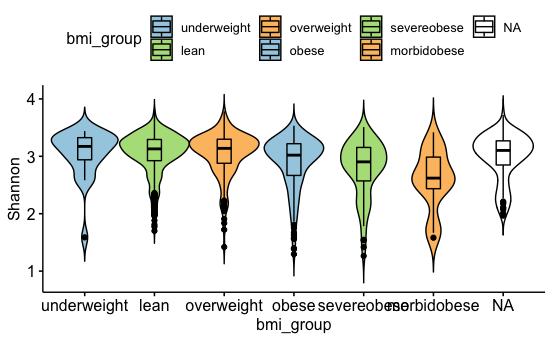

```r
# CREATING VIOLIN PLOT
# the number in the palettes must equal the number of groups in bmi.pairs
p1 <- ggviolin(ps1.meta, x = "bmi_group", y = "Shannon",
 add = "boxplot", fill = "bmi_group", palette = c("#a6cee3", "#b2df8a", "#fdbf6f","#a6cee3", "#b2df8a", "#fdbf6f")) #
print(p1)
```

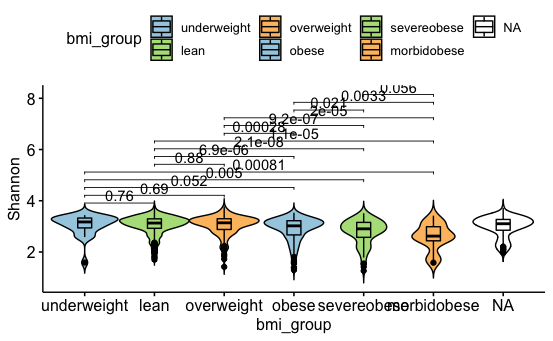

```r
# Pairwise comparision using non-parametric test (Wilcoxon test).
p1 <- p1 + stat_compare_means(comparisons = bmi.pairs)
print(p1)
```

```r
####### RICHNESS #######
tab <- richness(pseq)
kable(head(tab))
```

|  | 0 | 20 | 50 | 80 |
| --- | --- | --- | --- | --- |
| Sample-1 | 109 | 99 | 60 | 25 |
| Sample-2 | 110 | 99 | 63 | 34 |
| Sample-3 | 109 | 99 | 59 | 13 |
| Sample-4 | 111 | 100 | 67 | 25 |
| Sample-5 | 109 | 98 | 60 | 27 |
| Sample-6 | 109 | 99 | 64 | 18 |

```r
stargazer(tab, type = "text",summary = NULL)
```

```
==========================================================
Statistic   N    Mean   St. Dev. Min Pctl(25) Pctl(75) Max
----------------------------------------------------------
0         1,172 113.020  4.170   107   111      114    130
20        1,172 103.821  4.617   95    100      107    130
50        1,172 64.996   5.029   45     62       68    89
80        1,172 25.998   6.812    5     22       31    50
----------------------------------------------------------
```

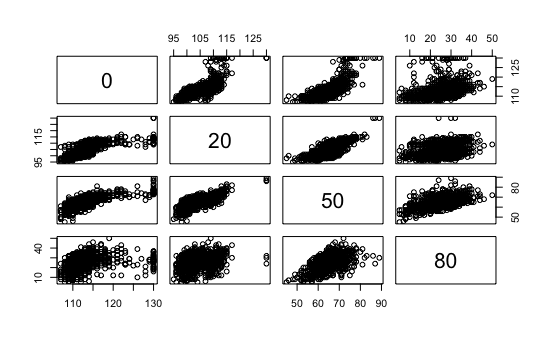

```r
plot(tab)
```

```r
###### DOMINANCE #####
# The dominance index refers to the abundance of the most abundant species. Various dominance indices are available (see the function help for a list of options).
# Absolute abundances for the single most abundant taxa in each sample
tab <- dominance(pseq, index = "all")
kable(head(tab))
```

|  | dbp | dmn | absolute | relative | simpson | core_abundance | gini |
| --- | --- | --- | --- | --- | --- | --- | --- |
| Sample-1 | 0.1758679 | 0.3377921 | 84316 | 0.1758679 | 0.0769613 | 1 | 0.8486688 |
| Sample-2 | 0.1716273 | 0.2820096 | 109940 | 0.1716273 | 0.0602281 | 1 | 0.8186840 |
| Sample-3 | 0.2793253 | 0.3985027 | 125664 | 0.2793253 | 0.1149041 | 1 | 0.8805150 |
| Sample-4 | 0.1957585 | 0.3813535 | 134094 | 0.1957585 | 0.0933541 | 1 | 0.8601541 |
| Sample-5 | 0.1685621 | 0.3332058 | 127719 | 0.1685621 | 0.0815435 | 1 | 0.8667646 |
| Sample-6 | 0.2271913 | 0.3799754 | 113490 | 0.2271913 | 0.1033435 | 1 | 0.8729719 |

```r
stargazer(tab, type = "text",summary = NULL)
```

```
=============================================================================
Statistic        N      Mean      St. Dev.    Min   Pctl(25) Pctl(75)   Max
-----------------------------------------------------------------------------
dbp            1,172    0.260       0.128    0.076   0.169    0.309    0.745
dmn            1,172    0.382       0.131    0.145   0.290    0.453    0.851
absolute       1,172 207,398.400 169,623.700 10,752 99,333.8 245,160  944,002
relative       1,172    0.260       0.128    0.076   0.169    0.309    0.745
simpson        1,172    0.121       0.085    0.036   0.069    0.135    0.567
core_abundance 1,172    1.000       0.000      1       1        1        1
gini           1,172    0.859       0.035    0.730   0.836    0.880    0.957
-----------------------------------------------------------------------------
```

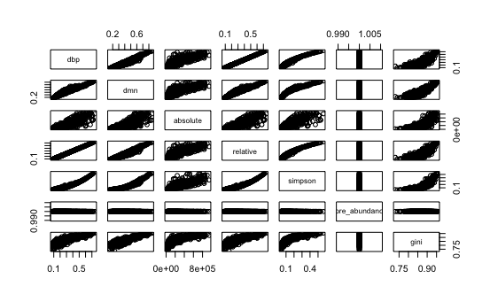

```r
plot(tab)
```

```r
######### RARENESS and low abundance ######
tab <- rarity(pseq, index = "all")
kable(head(tab))
```

|  | log_modulo_skewness | low_abundance | noncore_abundance | rare_abundance |
| --- | --- | --- | --- | --- |
| Sample-1 | 2.060324 | 0.0246043 | 0 | 0 |
| Sample-2 | 2.058091 | 0.0199587 | 0 | 0 |
| Sample-3 | 2.056895 | 0.0393057 | 0 | 0 |
| Sample-4 | 2.059333 | 0.0249986 | 0 | 0 |
| Sample-5 | 2.059235 | 0.0237021 | 0 | 0 |
| Sample-6 | 2.060673 | 0.0384898 | 0 | 0 |

```r
stargazer(tab, type = "text",summary = NULL)
```

```
======================================================================
Statistic             N   Mean  St. Dev.  Min  Pctl(25) Pctl(75)  Max
----------------------------------------------------------------------
log_modulo_skewness 1,172 2.059  0.003   2.033  2.058    2.061   2.061
low_abundance       1,172 0.034  0.006   0.016  0.030    0.037   0.055
noncore_abundance   1,172 0.000  0.000     0      0        0       0
rare_abundance      1,172 0.000  0.000     0      0        0       0
----------------------------------------------------------------------
```

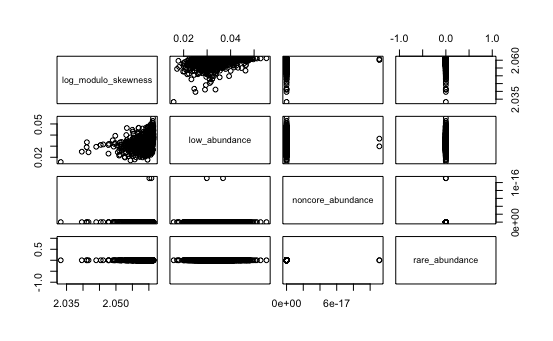

```r
plot(tab)
```

```r
#### COVERAGE
# The coverage index gives the number of groups needed to have a given proportion of the ecosystem occupied (by default 0.5 ie 50%).
tab <- coverage(pseq, threshold = 0.5)
kable(head(tab))
```

|  | x |
| --- | --- |
| Sample-1 | 5 |
| Sample-2 | 7 |
| Sample-3 | 4 |
| Sample-4 | 4 |
| Sample-5 | 4 |
| Sample-6 | 3 |

```r
stargazer(tab, type = "text",summary = NULL)
```

[output not shown]

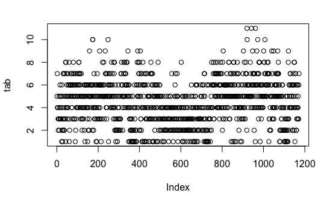

```r
plot(tab)
```

```r
#### ABUNDANCE
# The core_abundance function refers to the relative proportion of the core species. Non-core abundance provides the complement (1-x; see noncore_abundance).
tab <- core_abundance(pseq, detection = .1/100, prevalence = 50/100)
kable(head(tab))
```

|  | x |
| --- | --- |
| Sample-1 | 1 |
| Sample-2 | 1 |
| Sample-3 | 1 |
| Sample-4 | 1 |
| Sample-5 | 1 |
| Sample-6 | 1 |

```r
stargazer(tab, type = "text",summary = NULL)
```

[output not shown]

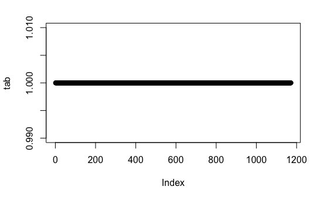

```r
plot(tab)
```

```r
##### GINI INDEX
#Gini index is a common measure for inequality in economical income. The inverse gini index (1/x) can also be used as a community diversity measure.
tab <- inequality(pseq)
kable(head(tab))
```

|  | x |
| --- | --- |
| Sample-1 | 0.8486688 |
| Sample-2 | 0.8186840 |
| Sample-3 | 0.8805150 |
| Sample-4 | 0.8601541 |
| Sample-5 | 0.8667646 |
| Sample-6 | 0.8729719 |

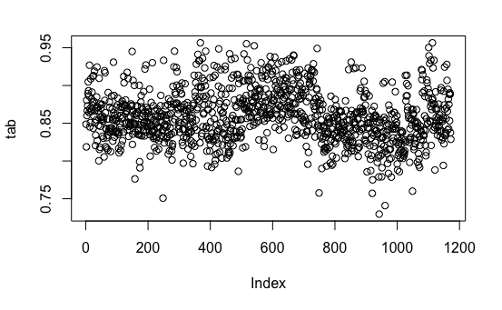

```r
plot(tab)
```

```r
###### EVENNESS
# Various evenness measures are also available.
tab <- evenness(pseq, "all")
kable(head(tab))
```

|  | camargo | pielou | simpson | evar | bulla |
| --- | --- | --- | --- | --- | --- |
| Sample-1 | 0.1513312 | 0.6553063 | 0.0999503 | 0.0665828 | 0.2902021 |
| Sample-2 | 0.1813160 | 0.6977115 | 0.1277196 | 0.0599369 | 0.3293462 |
| Sample-3 | 0.1194850 | 0.5888204 | 0.0669454 | 0.0738372 | 0.2381299 |
| Sample-4 | 0.1398459 | 0.6283784 | 0.0823993 | 0.0644078 | 0.2896032 |
| Sample-5 | 0.1332354 | 0.6321168 | 0.0943338 | 0.0611757 | 0.2662343 |
| Sample-6 | 0.1270281 | 0.6051747 | 0.0744343 | 0.0701696 | 0.2649482 |

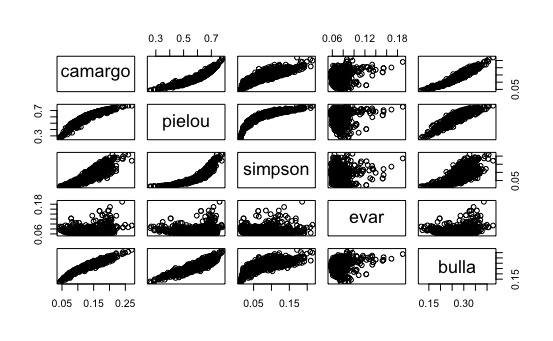

```r
plot(tab)
```

MICROBIOME COMPOSITION

[figure not shown]

```r
# Just use prevalent taxa to speed up examples
# (not absolute counts used in this example)
# Pick sample subset
library(phyloseq)
library(hrbrthemes)
library(gcookbook)
library(tidyverse)
library(dplyr)
library(microbiome)
######## THIS ALTERED THE CORE DATA ###############
#pseq <- core(atlas1006, detection = 10^3, prevalence = 95/100)
#pseq2 <- subset_samples(pseq, group == "DI" & nationality == "AFR" & timepoint.within.group == 1)
# Try another theme
# from https://github.com/hrbrmstr/hrbrthemes
# Limit the analysis on core taxa and specific sample group
p <- plot_composition(pseq,
              taxonomic.level = "OTU",
                      sample.sort = "nationality",
                      x.label = "nationality") +
     guides(fill = guide_legend(ncol = 1)) +
     scale_y_percent() +
     labs(x = "Samples", y = "Relative abundance (%)",
                                   title = "Relative abundance data",
                                   subtitle = "Subtitle",
                                   caption = "Caption text.") +
     theme_ipsum(grid="Y")
print(p)
```

[figure not shown]

```r
# Averaged by group
p <- plot_composition(pseq,
                      average_by = "bmi_group", transform = "compositional")
print(p)
```

```r
tmp <- plot_composition(pseq, plot.type = "heatmap", transform = "compositional",
            sample.sort = "neatmap", otu.sort = "neatmap", mar = c(6, 13, 1, 1))
print(tmp)
```

[output not shown]